# 1 Similar recovery time of microbial functions from fungicide stress across biogeographical regions

##### 1.6.1.0.2 Flagellospora curvula

```r
mod1_DE_Fc <- lm(Flagellospora.curvula ~ fungicide + cycle  +
             fungicide:cycle,
           data = data_conid_DE)
```

Check model fitting

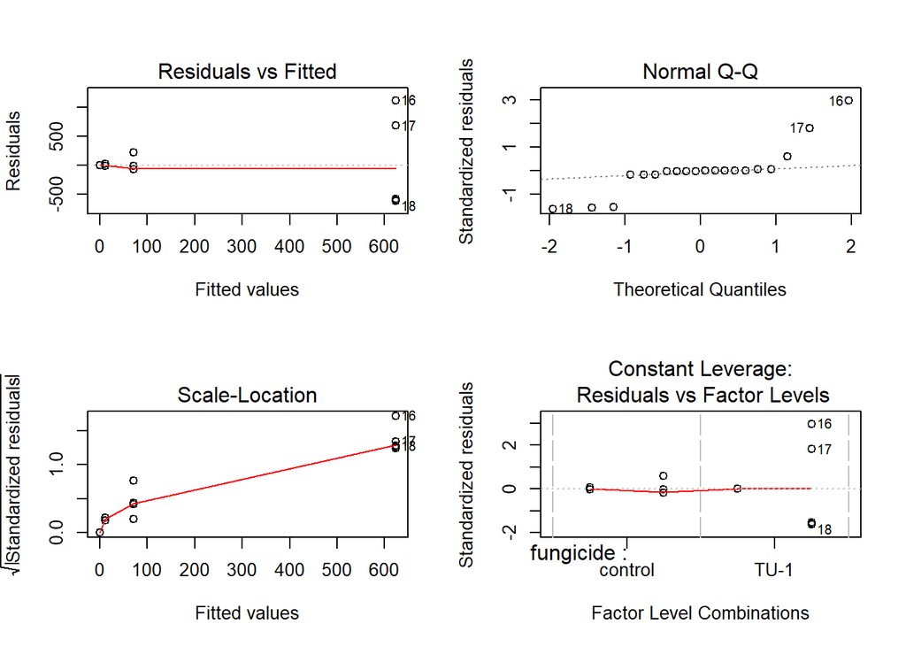

```r
par(mfrow = c(2, 2))
plot(mod1_DE_Fc)
```

ok

```r
drop1(mod1_DE_Fc, test = 'F')
```

```
## Single term deletions
##
## Model:
## Flagellospora.curvula ~ fungicide + cycle + fungicide:cycle
##                 Df Sum of Sq     RSS    AIC F value Pr(>F)
## <none>                       2860738 245.42
## fungicide:cycle  1    397548 3258286 246.02  2.2235 0.1554
```

Interaction not significant, reduce model.

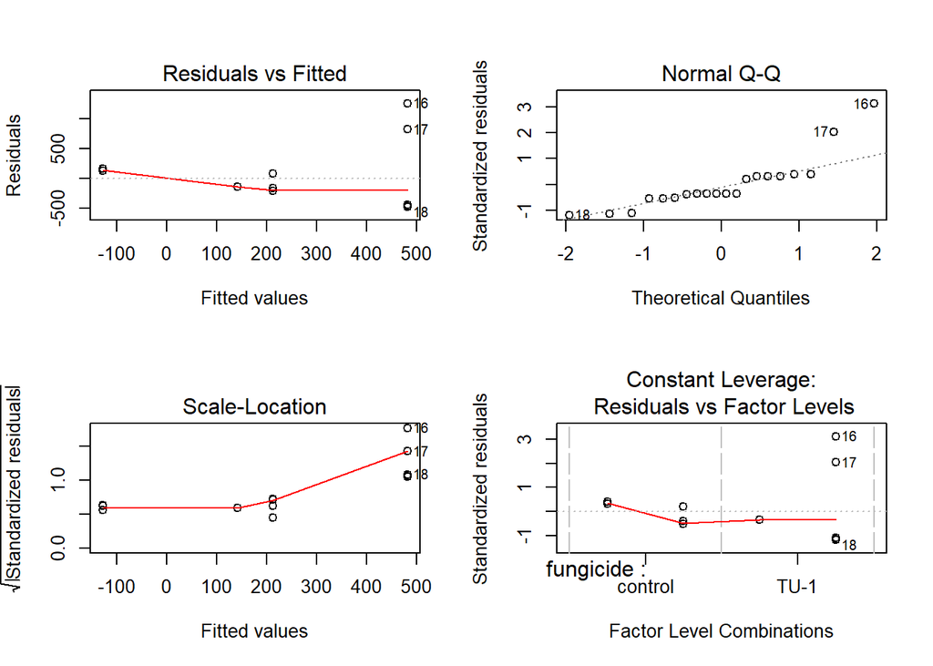

```r
mod1_DE_Fc_wo2 <- lm(Flagellospora.curvula ~ fungicide + cycle,
           data = data_conid_DE)

par(mfrow = c(2, 2))
plot(mod1_DE_Fc_wo2)
```

ok

```r
drop1(mod1_DE_Fc_wo2, test = 'F')
```

```
## Single term deletions
##
## Model:
## Flagellospora.curvula ~ fungicide + cycle
##           Df Sum of Sq     RSS    AIC F value  Pr(>F)
## <none>                 3258286 246.02
## fungicide  1    363756 3622042 246.14  1.8979 0.18618
## cycle      1    582958 3841244 247.31  3.0416 0.09921 .
## ---
## Signif. codes:  0 '***' 0.001 '**' 0.01 '*' 0.05 '.' 0.1 ' ' 1
```

##### 1.6.1.0.3 Tetrachaetum elegans

```r
mod1_DE_Te <- lm(Tetrachaetum.elegans ~ fungicide + cycle  +
             fungicide:cycle,
           data = data_conid_DE)
```

Check model fitting

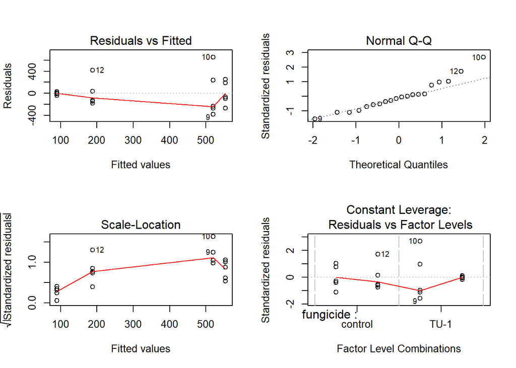

```r
par(mfrow = c(2, 2))
plot(mod1_DE_Te)
```

ok

```r
drop1(mod1_DE_Te, test = 'F')
```

```
## Single term deletions
##
## Model:
## Tetrachaetum.elegans ~ fungicide + cycle + fungicide:cycle
##                 Df Sum of Sq     RSS    AIC F value Pr(>F)
## <none>                       1198572 228.02
## fungicide:cycle  1    5295.6 1203867 226.11  0.0707 0.7937
```

Interaction not significant, reduce model.

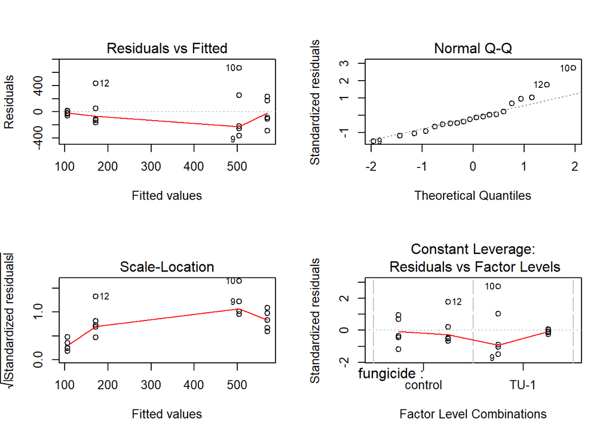

```r
mod1_DE_Te_wo2 <- lm(Tetrachaetum.elegans ~ fungicide + cycle,
           data = data_conid_DE)

par(mfrow = c(2, 2))
plot(mod1_DE_Te_wo2)
```

ok

```r
drop1(mod1_DE_Te_wo2, test = 'F')
```

```
## Single term deletions
##
## Model:
## Tetrachaetum.elegans ~ fungicide + cycle
##           Df Sum of Sq     RSS    AIC F value   Pr(>F)
## <none>                 1203867 226.11
## fungicide  1     21710 1225577 224.46  0.3066 0.587002
## cycle      1    792017 1995884 234.22 11.1842 0.003844 **
## ---
## Signif. codes:  0 '***' 0.001 '**' 0.01 '*' 0.05 '.' 0.1 ' ' 1
```

##### 1.6.1.0.4 Tetracladium sp.

```r
mod1_DE_Ts <- lm(Tetracladium.sp. ~ fungicide + cycle  +
             fungicide:cycle,
           data = data_conid_DE)
```

Check model fitting

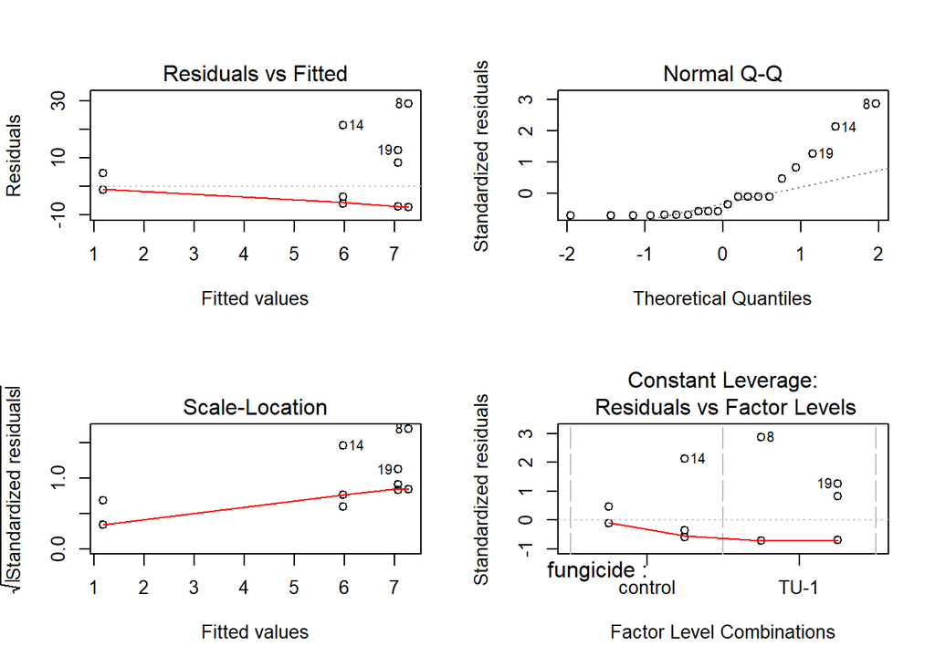

```r
par(mfrow = c(2, 2))
plot(mod1_DE_Ts)
```

ok

```r
drop1(mod1_DE_Ts, test = 'F')
```

```
## Single term deletions
##
## Model:
## Tetracladium.sp. ~ fungicide + cycle + fungicide:cycle
##                 Df Sum of Sq    RSS     AIC F value Pr(>F)
## <none>                       2062.3 100.717
## fungicide:cycle  1    31.327 2093.7  99.019   0.243 0.6287
```

Interaction not significant, reduce model.

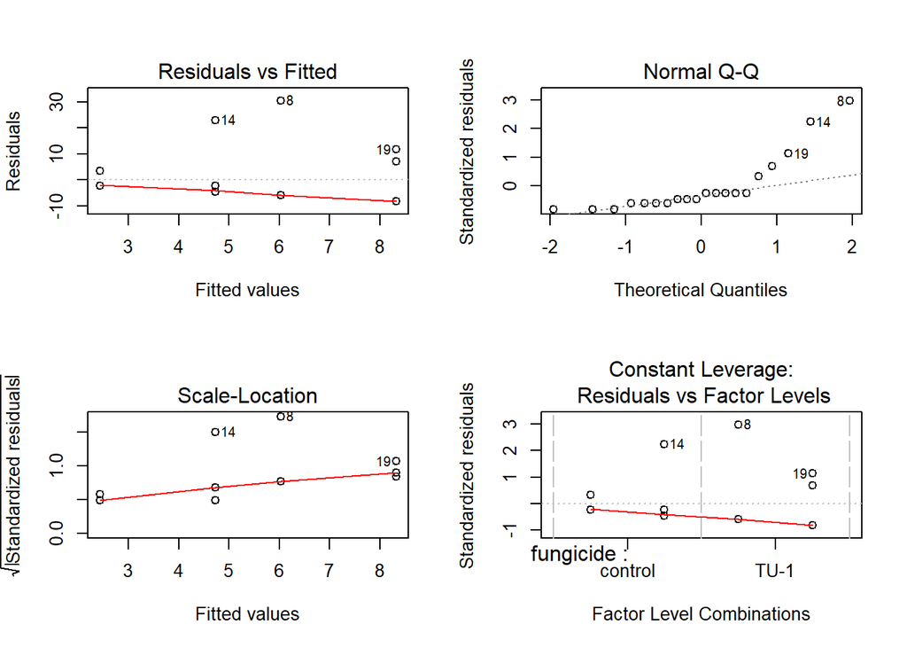

```r
mod1_DE_Ts_wo2 <- lm(Tetracladium.sp. ~ fungicide + cycle,
           data = data_conid_DE)

par(mfrow = c(2, 2))
plot(mod1_DE_Ts_wo2)
```

ok

```r
drop1(mod1_DE_Ts_wo2, test = 'F')
```

```
## Single term deletions
##
## Model:
## Tetracladium.sp. ~ fungicide + cycle
##           Df Sum of Sq    RSS    AIC F value Pr(>F)
## <none>                 2093.7 99.019
## fungicide  1    64.751 2158.4 97.628  0.5258 0.4783
## cycle      1    26.275 2119.9 97.268  0.2133 0.6500
```

##### 1.6.1.0.5 Tetracladium marchalianum

```r
mod1_DE_Tm <- lm(Tetracladium.marchalianum ~ fungicide + cycle  +
             fungicide:cycle,
           data = data_conid_DE)
```

Check model fitting

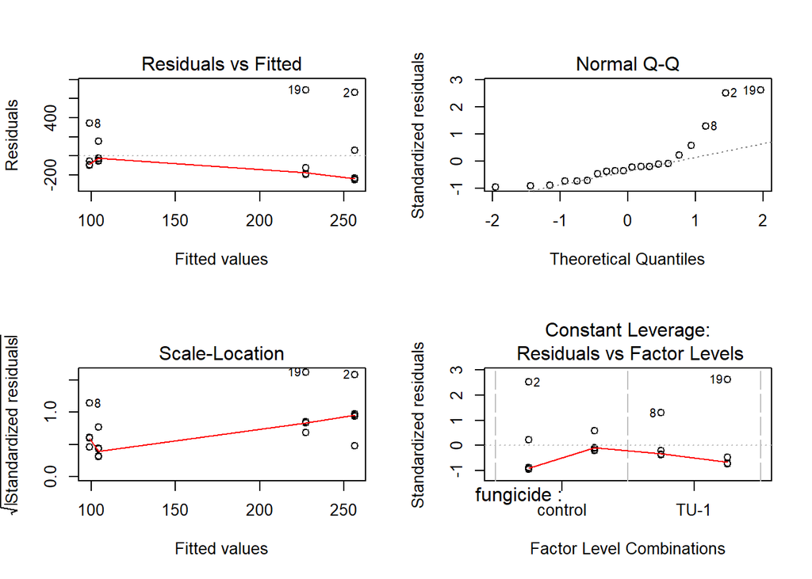

```r
par(mfrow = c(2, 2))
plot(mod1_DE_Tm)
```

ok

```r
drop1(mod1_DE_Tm, test = 'F')
```

```
## Single term deletions
##
## Model:
## Tetracladium.marchalianum ~ fungicide + cycle + fungicide:cycle
##                 Df Sum of Sq     RSS    AIC F value Pr(>F)
## <none>                       1391135 231.00
## fungicide:cycle  1     98813 1489948 230.37  1.1365 0.3022
```

Interaction not significant, reduce model.

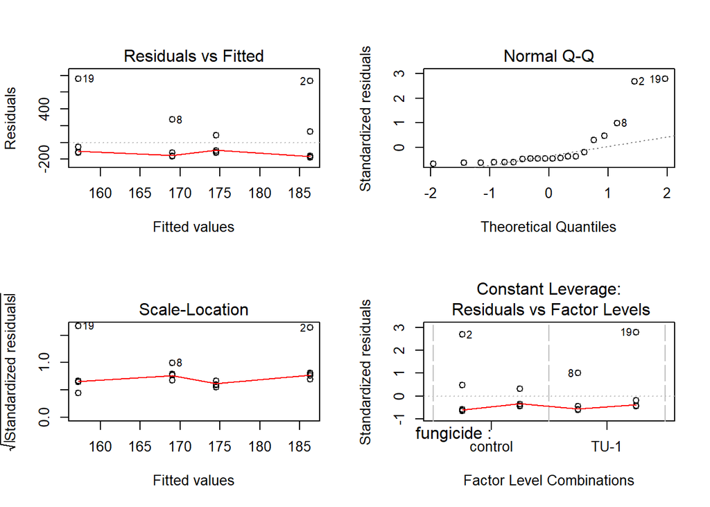

```r
mod1_DE_Tm_wo2 <- lm(Tetracladium.marchalianum ~ fungicide + cycle,
           data = data_conid_DE)

par(mfrow = c(2, 2))
plot(mod1_DE_Tm_wo2)
```

ok

```r
drop1(mod1_DE_Tm_wo2, test = 'F')
```

```
## Single term deletions
##
## Model:
## Tetracladium.marchalianum ~ fungicide + cycle
##           Df Sum of Sq     RSS    AIC F value Pr(>F)
## <none>                 1489948 230.37
## fungicide  1   1498.53 1491447 228.39  0.0171 0.8975
## cycle      1    695.37 1490644 228.38  0.0079 0.9301
```

### 1.6.2 Denmark

Looking closer at following species: * Articulospora tetracladia * Flagellospora curvula * Tetrachaetum elegans * Mycocentrospora clavata * Tetracladium sp. * Tetracladium marchalianum

##### 1.6.2.0.1 Articulospora tetracladia

```r
mod1_DK_At <- lm(Articulospora.tetracladia ~ fungicide + cycle  +
             fungicide:cycle,
           data = data_conid_DK)
```

Check model fitting

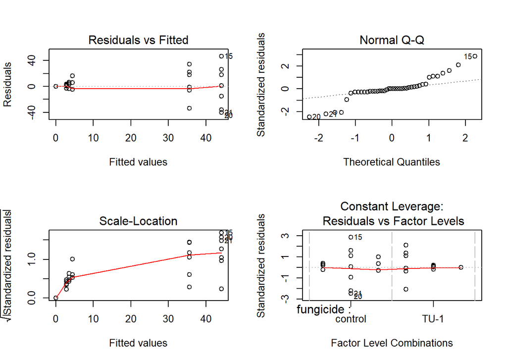

```r
par(mfrow = c(2, 2))
plot(mod1_DK_At)
```

ok

```r
drop1(mod1_DK_At, test = 'F')
```

```
## Single term deletions
##
## Model:
## Articulospora.tetracladia ~ fungicide + cycle + fungicide:cycle
##                 Df Sum of Sq   RSS    AIC F value    Pr(>F)
## <none>                       11176 246.52
## fungicide:cycle  2    9404.3 20580 268.17  15.147 1.686e-05 ***
## ---
## Signif. codes:  0 '***' 0.001 '**' 0.01 '*' 0.05 '.' 0.1 ' ' 1
```

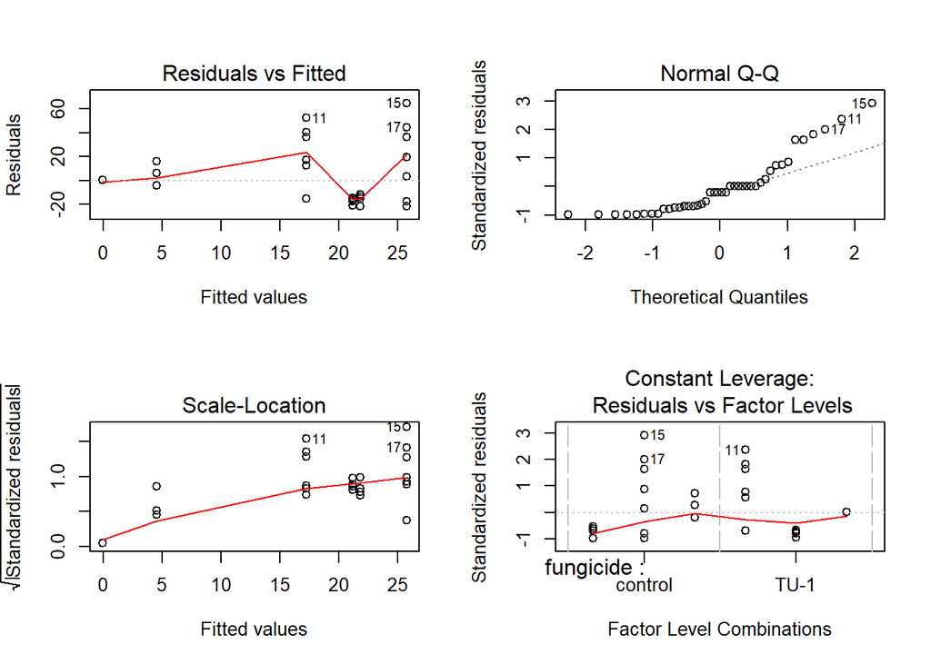

```r
mod1_DK_At2 <- lm(Articulospora.tetracladia ~ fungicide + cycle,
           data = data_conid_DK)

par(mfrow = c(2, 2))
plot(mod1_DK_At2)
```

ok

```r
drop1(mod1_DK_At2, test = 'F')
```

```
## Single term deletions
##
## Model:
## Articulospora.tetracladia ~ fungicide + cycle
##           Df Sum of Sq   RSS    AIC F value  Pr(>F)
## <none>                 20580 268.17
## fungicide  1     220.0 20800 266.61  0.4063 0.52770
## cycle      2    3577.2 24157 270.90  3.3026 0.04759 *
## ---
## Signif. codes:  0 '***' 0.001 '**' 0.01 '*' 0.05 '.' 0.1 ' ' 1
```

##### 1.6.2.0.2 Flagellospora curvula

```r
mod1_DK_Fc <- lm(Flagellospora.curvula ~ fungicide + cycle  +
             fungicide:cycle,
           data = data_conid_DK)
```

Check model fitting

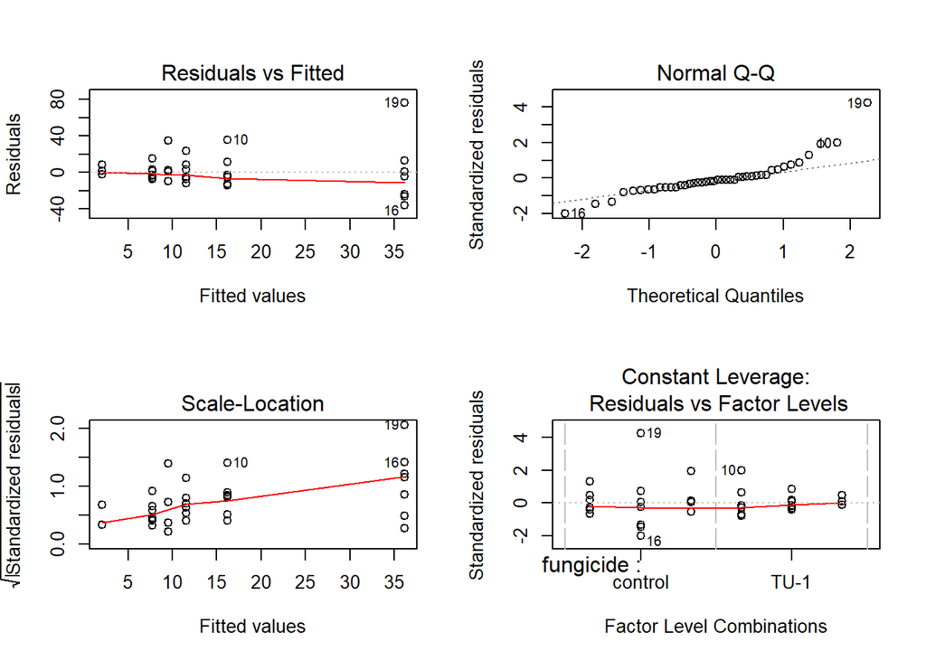

```r
par(mfrow = c(2, 2))
plot(mod1_DK_Fc)
```

ok

```r
drop1(mod1_DK_Fc, test = 'F')
```

```
## Single term deletions
##
## Model:
## Flagellospora.curvula ~ fungicide + cycle + fungicide:cycle
##                 Df Sum of Sq   RSS    AIC F value  Pr(>F)
## <none>                       13624 254.84
## fungicide:cycle  2    1959.5 15584 256.49  2.5889 0.08903 .
## ---
## Signif. codes:  0 '***' 0.001 '**' 0.01 '*' 0.05 '.' 0.1 ' ' 1
```

Interaction not significant, reduce model.

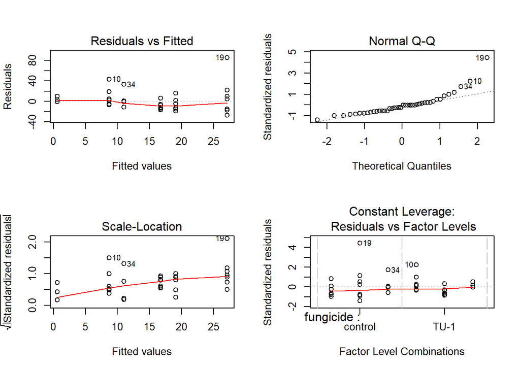

```r
mod1_DK_Fc_wo2 <- lm(Flagellospora.curvula ~ fungicide + cycle,
           data = data_conid_DK)

par(mfrow = c(2, 2))
plot(mod1_DK_Fc_wo2)
```

ok

```r
drop1(mod1_DK_Fc_wo2, test = 'F')
```

```
## Single term deletions
##
## Model:
## Flagellospora.curvula ~ fungicide + cycle
##           Df Sum of Sq   RSS    AIC F value Pr(>F)
## <none>                 15584 256.49
## fungicide  1    1135.2 16719 257.44  2.7680 0.1044
## cycle      2    1823.8 17408 257.13  2.2236 0.1221
```

##### 1.6.2.0.3 Tetrachaetum elegans

```r
mod1_DK_Te <- lm(Tetrachaetum.elegans ~ fungicide + cycle  +
             fungicide:cycle,
           data = data_conid_DK)
```

Check model fitting

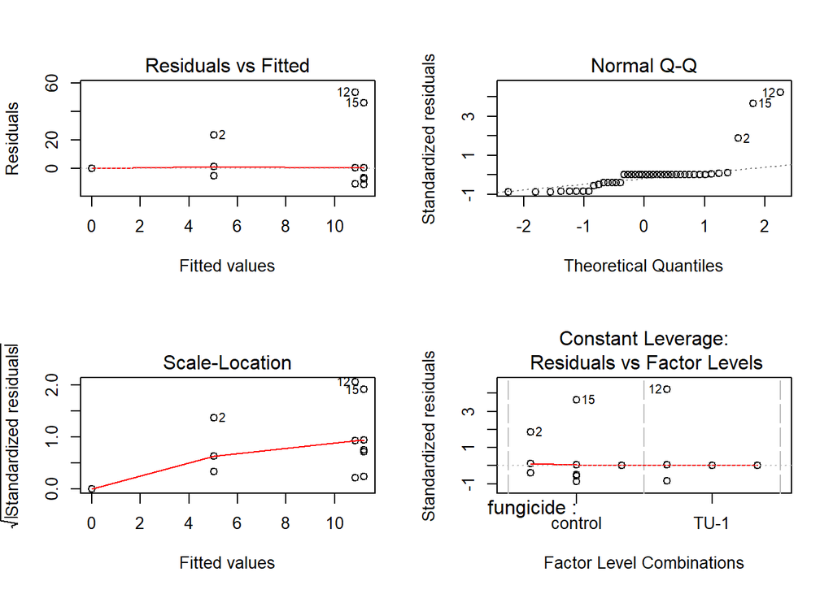

```r
par(mfrow = c(2, 2))
plot(mod1_DK_Te)
```

ok

```r
drop1(mod1_DK_Te, test = 'F')
```

```
## Single term deletions
##
## Model:
## Tetrachaetum.elegans ~ fungicide + cycle + fungicide:cycle
##                 Df Sum of Sq    RSS    AIC F value Pr(>F)
## <none>                       6775.7 225.50
## fungicide:cycle  2    523.18 7298.8 224.63  1.3899 0.2622
```

Interaction not significant, reduce model.

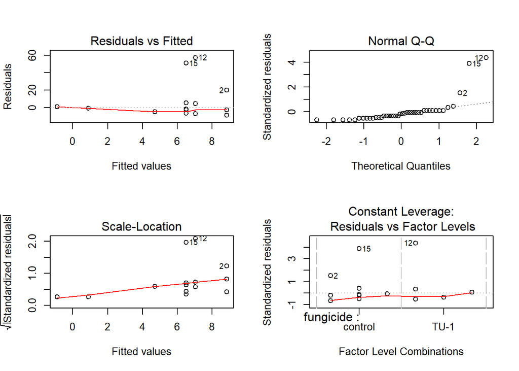

```r
mod1_DK_Te_wo2 <- lm(Tetrachaetum.elegans ~ fungicide + cycle,
           data = data_conid_DK)

par(mfrow = c(2, 2))
plot(mod1_DK_Te_wo2)
```

ok

```r
drop1(mod1_DK_Te_wo2, test = 'F')
```

```
## Single term deletions
##
## Model:
## Tetrachaetum.elegans ~ fungicide + cycle
##           Df Sum of Sq    RSS    AIC F value Pr(>F)
## <none>                 7298.8 224.63
## fungicide  1     33.94 7332.8 222.82  0.1767 0.6766
## cycle      2    465.45 7764.3 223.22  1.2116 0.3090
```

##### 1.6.2.0.4 Mycocentrospora clavata

```r
mod1_DK_Mc <- lm(Mycocentrospora.clavata ~ fungicide + cycle  +
             fungicide:cycle,
           data = data_conid_DK)
```

Check model fitting

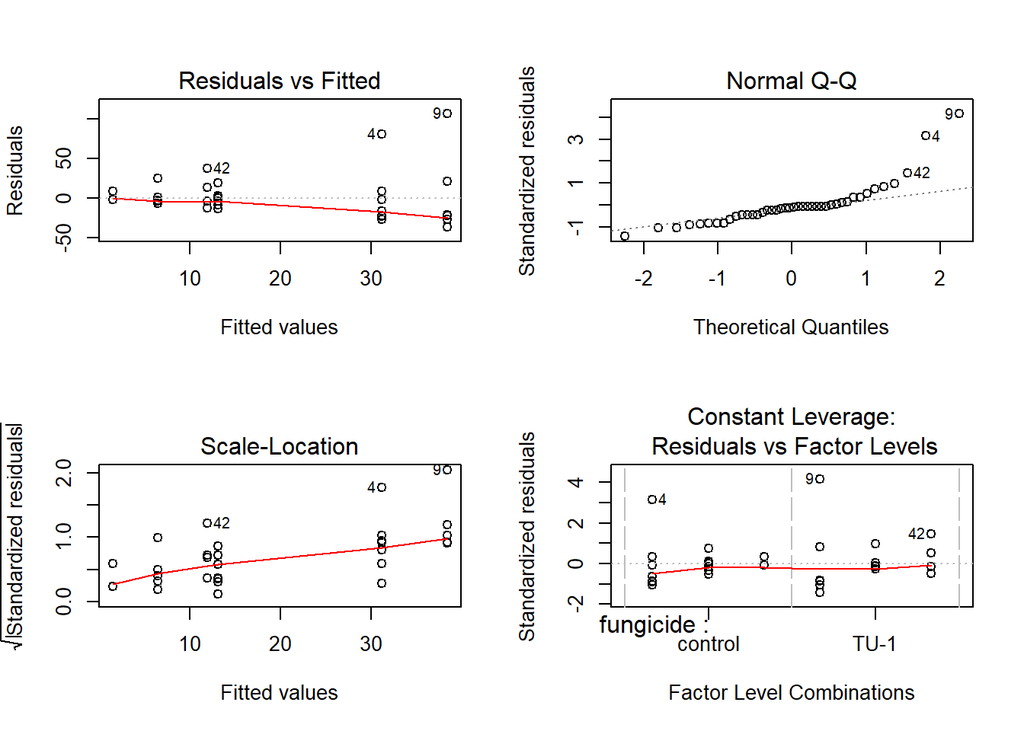

```r
par(mfrow = c(2, 2))
plot(mod1_DK_Mc)
```

ok

```r
drop1(mod1_DK_Mc, test = 'F')
```

```
## Single term deletions
##
## Model:
## Mycocentrospora.clavata ~ fungicide + cycle + fungicide:cycle
##                 Df Sum of Sq   RSS    AIC F value Pr(>F)
## <none>                       27743 284.71
## fungicide:cycle  2    580.13 28323 281.58  0.3764  0.689
```

Interaction not significant, reduce model.

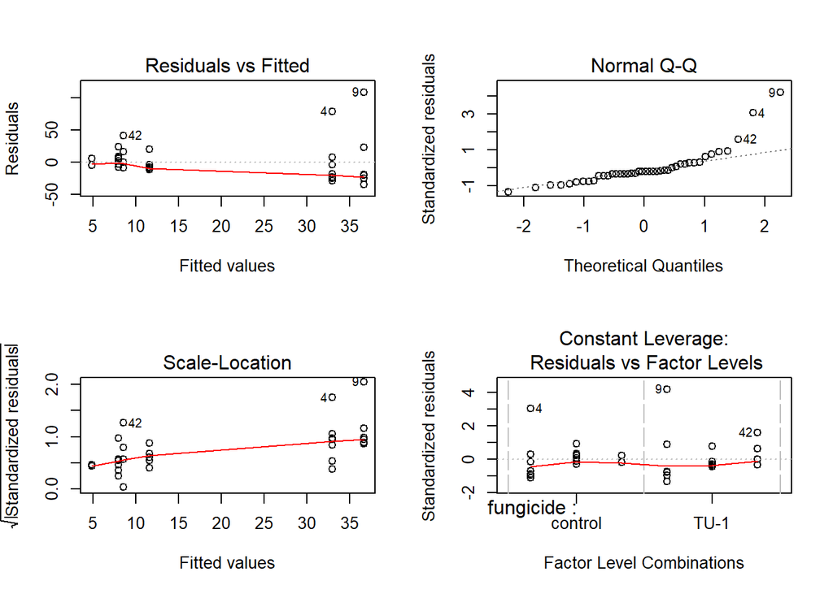

```r
mod1_DK_Mc_wo2 <- lm(Mycocentrospora.clavata ~ fungicide + cycle,
           data = data_conid_DK)

par(mfrow = c(2, 2))
plot(mod1_DK_Mc_wo2)
```

ok

```r
drop1(mod1_DK_Mc_wo2, test = 'F')
```

```
## Single term deletions
##
## Model:
## Mycocentrospora.clavata ~ fungicide + cycle
##           Df Sum of Sq   RSS    AIC F value  Pr(>F)
## <none>                 28323 281.58
## fungicide  1     142.2 28466 279.79  0.1908 0.66473
## cycle      2    6640.0 34963 286.42  4.4543 0.01829 *
## ---
## Signif. codes:  0 '***' 0.001 '**' 0.01 '*' 0.05 '.' 0.1 ' ' 1
```

##### 1.6.2.0.5 Tetracladium sp.

```r
mod1_DK_Ts <- lm(Tetracladium.sp. ~ fungicide + cycle  +
             fungicide:cycle,
           data = data_conid_DK)
```

Check model fitting

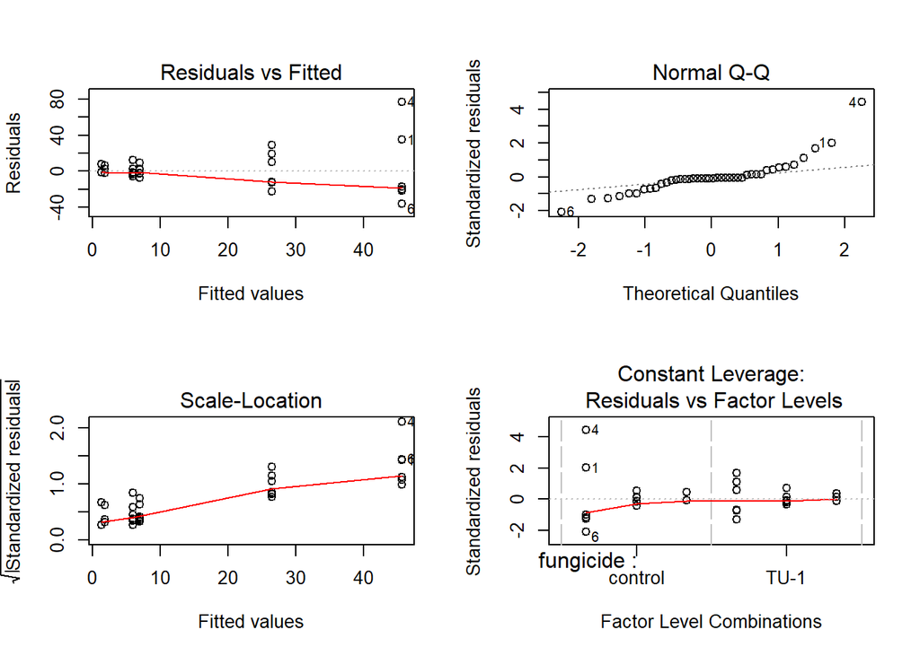

```r
par(mfrow = c(2, 2))
plot(mod1_DK_Ts)
```

ok

```r
drop1(mod1_DK_Ts, test = 'F')
```

```
## Single term deletions
##
## Model:
## Tetracladium.sp. ~ fungicide + cycle + fungicide:cycle
##                 Df Sum of Sq   RSS    AIC F value Pr(>F)
## <none>                       12611 251.59
## fungicide:cycle  2    842.04 13453 250.31  1.2019 0.3124
```

Interaction not significant, reduce model.

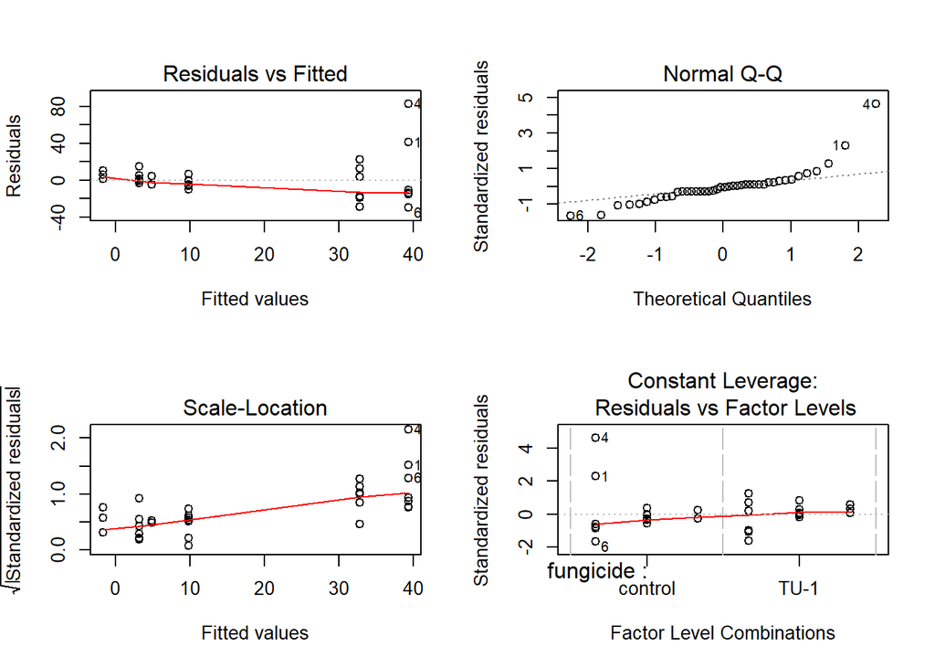

```r
mod1_DK_Ts_wo <- lm(Tetracladium.sp. ~ fungicide + cycle,
           data = data_conid_DK)

par(mfrow = c(2, 2))
plot(mod1_DK_Ts_wo)
```

ok

```r
drop1(mod1_DK_Ts_wo, test = 'F')
```

```
## Single term deletions
##
## Model:
## Tetracladium.sp. ~ fungicide + cycle
##           Df Sum of Sq   RSS    AIC F value    Pr(>F)
## <none>                 13453 250.31
## fungicide  1     453.7 13907 249.70  1.2815    0.2647
## cycle      2    9778.0 23231 269.25 13.8098 3.106e-05 ***
## ---
## Signif. codes:  0 '***' 0.001 '**' 0.01 '*' 0.05 '.' 0.1 ' ' 1
```

##### 1.6.2.0.6 Tetracladium marchalianum

```r
mod1_DK_Tm <- lm(Tetracladium.marchalianum ~ fungicide + cycle  +
             fungicide:cycle,
           data = data_conid_DK)
```

Check model fitting

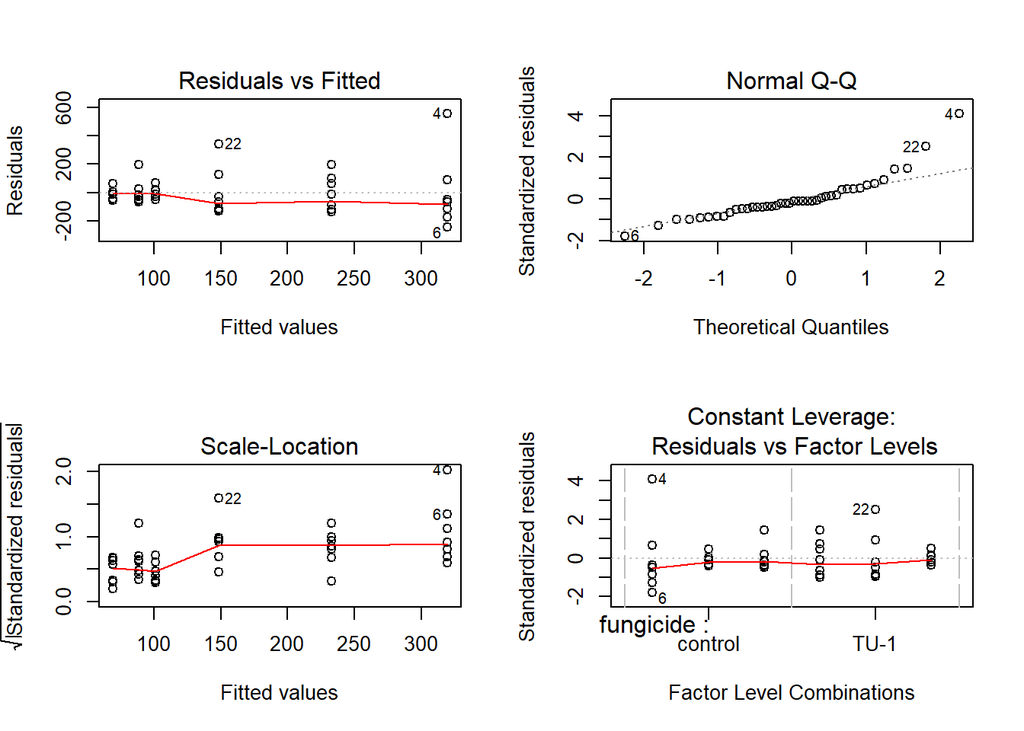

```r
par(mfrow = c(2, 2))
plot(mod1_DK_Tm)
```

ok

```r
drop1(mod1_DK_Tm, test = 'F')
```

```
## Single term deletions
##
## Model:
## Tetracladium.marchalianum ~ fungicide + cycle + fungicide:cycle
##                 Df Sum of Sq    RSS    AIC F value Pr(>F)
## <none>                       780932 424.88
## fungicide:cycle  2     48782 829714 423.43  1.1244  0.336
```

Interaction not significant, reduce model.

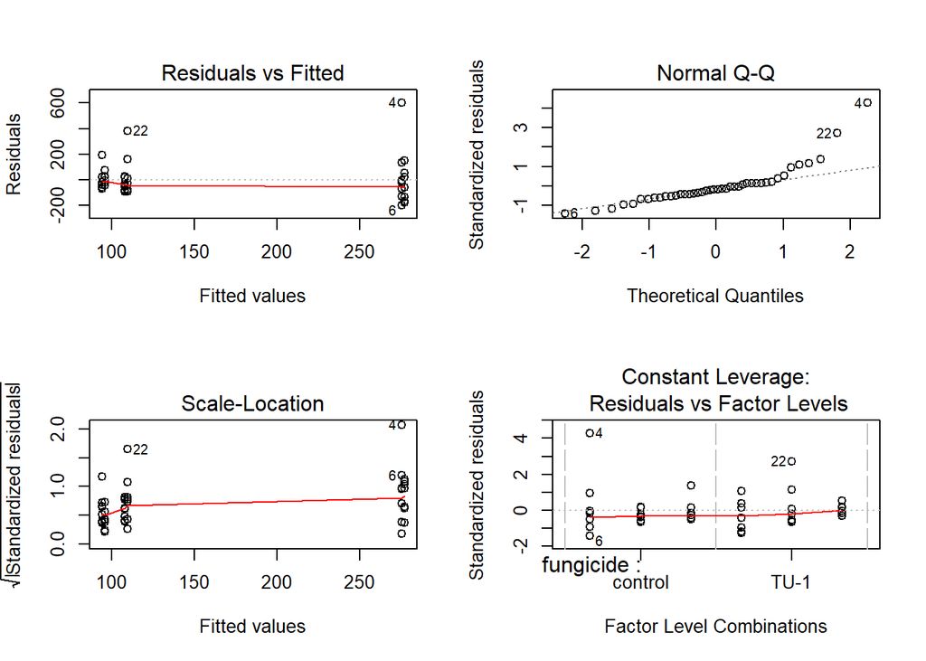

```r
mod1_DK_Tm_wo <- lm(Tetracladium.marchalianum ~ fungicide + cycle,
           data = data_conid_DK)

par(mfrow = c(2, 2))
plot(mod1_DK_Tm_wo)
```

ok

```r
drop1(mod1_DK_Tm_wo, test = 'F')
```

```
## Single term deletions
##
## Model:
## Tetracladium.marchalianum ~ fungicide + cycle
##           Df Sum of Sq     RSS    AIC F value   Pr(>F)
## <none>                  829714 423.43
## fungicide  1        34  829748 421.43  0.0016 0.968525
## cycle      2    283863 1113577 431.79  6.5003 0.003732 **
## ---
## Signif. codes:  0 '***' 0.001 '**' 0.01 '*' 0.05 '.' 0.1 ' ' 1
```

## 1.7 Preparing Fig.2: functional response

We want to display the Effect size and its standard deviation of the fungicide treatment in relation to control treatments.

### 1.7.1 Calculating effect sizes of DLM + the respective standard deviations

```r
s_Germany <- as.data.frame(summary(lsm_Germany))
s_Germany$region <- c("Germany")
control <- s_Germany[s_Germany$fungicide =="control",]
names(control)[3] <- c("mean_control")
names(control)[6] <- c("lower_control")
names(control)[7] <- c("upper_control")
s_Germany <- s_Germany[s_Germany$fungicide =="TU-1",]
names(s_Germany)[3] <- c("mean_TU-1")
s_Germany <- cbind(s_Germany, control[c(3,6,7)])
s_Germany$mean <- ((s_Germany$`mean_TU-1` - s_Germany$mean_control) /
                     s_Germany$mean_control)*100
s_Germany$lower_CI <- ((s_Germany$lower.CL - s_Germany$mean_control) /
                         s_Germany$mean_control)*100
s_Germany$upper_CI <- ((s_Germany$upper.CL - s_Germany$mean_control) /
                         s_Germany$mean_control)*100
s_Germany$lower_cont_CI <- ((s_Germany$lower_control - s_Germany$mean_control) /
                              s_Germany$mean_control)*100
s_Germany$upper_cont_CI <- ((s_Germany$upper_control - s_Germany$mean_control) /
                              s_Germany$mean_control)*100
s_Germany$sig <- c("*", " ", " ")
s_Germany$region <- as.factor(s_Germany$region)


s_Sweden <- as.data.frame(summary(lsm_Sweden))
s_Sweden$region <- c("Sweden")
control <- s_Sweden[s_Sweden$fungicide =="control",]
names(control)[3] <- c("mean_control")
names(control)[6] <- c("lower_control")
names(control)[7] <- c("upper_control")
s_Sweden <- s_Sweden[s_Sweden$fungicide =="TU-1",]
names(s_Sweden)[3] <- c("mean_TU-1")
s_Sweden <- cbind(s_Sweden, control[c(3,6,7)])
s_Sweden$mean <- ((s_Sweden$`mean_TU-1` - s_Sweden$mean_control) /
                    s_Sweden$mean_control)*100
s_Sweden$lower_CI <- ((s_Sweden$lower.CL - s_Sweden$mean_control) /
                        s_Sweden$mean_control)*100
s_Sweden$upper_CI <- ((s_Sweden$upper.CL - s_Sweden$mean_control) /
                        s_Sweden$mean_control)*100
s_Sweden$lower_cont_CI <- ((s_Sweden$lower_control - s_Sweden$mean_control) /
                             s_Sweden$mean_control)*100
s_Sweden$upper_cont_CI <- ((s_Sweden$upper_control - s_Sweden$mean_control) /
                             s_Sweden$mean_control)*100
s_Sweden$sig <- c("*", " ", " ")
s_Sweden$region <- as.factor(s_Sweden$region)

s_Denmark <- as.data.frame(summary(lsm_Denmark))
s_Denmark$region <- c("Denmark")
control <- s_Denmark[s_Denmark$fungicide =="control",]
names(control)[3] <- c("mean_control")
names(control)[6] <- c("lower_control")
names(control)[7] <- c("upper_control")
s_Denmark <- s_Denmark[s_Denmark$fungicide =="TU-1",]
names(s_Denmark)[3] <- c("mean_TU-1")
s_Denmark <- cbind(s_Denmark, control[c(3,6,7)])
s_Denmark$mean <- ((s_Denmark$`mean_TU-1` - s_Denmark$mean_control) /
                     s_Denmark$mean_control)*100
s_Denmark$lower_CI <- ((s_Denmark$lower.CL - s_Denmark$mean_control) /
                         s_Denmark$mean_control)*100
s_Denmark$upper_CI <- ((s_Denmark$upper.CL - s_Denmark$mean_control) /
                         s_Denmark$mean_control)*100
s_Denmark$lower_cont_CI <- ((s_Denmark$lower_control - s_Denmark$mean_control) /
                              s_Denmark$mean_control)*100
s_Denmark$upper_cont_CI <- ((s_Denmark$upper_control - s_Denmark$mean_control) /
                              s_Denmark$mean_control)*100
s_Denmark$sig <- c("*", "*", " ")
s_Denmark$region <- as.factor(s_Denmark$region)
```

### 1.7.2 preparing the single graphs

For Denmark

```r
p1 <-   ggplot(s_Denmark, aes(x = region)) +
  geom_pointrange(aes(y = mean, ymin = lower_CI, ymax = upper_CI))+
  geom_hline(aes(yintercept = 0), linetype = 'solid', colour="grey50") +
  geom_hline(aes(yintercept = lower_cont_CI), linetype = 'dashed') +
  geom_hline(aes(yintercept = upper_cont_CI), linetype = 'dashed') +
  facet_wrap(~cycle) +
  ylab('Changes in decomposed leaf mass [%]')+
  xlab("")+
  ylim(-80,31)+
  ggtitle("Denmark")+
  geom_text(aes(x=1,y=30,label=sig), cex=8) +
  theme_classic()+
  theme(axis.text.x = element_blank(),axis.ticks.x = element_blank(),
        axis.text.y = element_text(colour="black", size = 12),
        legend.position="none", strip.text.x = element_text(face = "bold"),
        text = element_text(size=14))
```

For Germany

```r
p2 <- ggplot(s_Germany, aes(x = region)) +
  geom_pointrange(aes(y = mean, ymin = lower_CI, ymax = upper_CI))+
  geom_hline(aes(yintercept = 0), linetype = 'solid', colour="grey50") +
  geom_hline(aes(yintercept = lower_cont_CI), linetype = 'dashed') +
  geom_hline(aes(yintercept = upper_cont_CI), linetype = 'dashed') +
  facet_wrap(~cycle) +
  ylab('')+
  xlab("")+
  ylim(-80,31)+
  ggtitle("Germany")+
  geom_text(aes(x=1,y=30,label=sig), cex=8) +
  theme_classic()+
  theme(axis.text.x = element_blank(),axis.ticks.x = element_blank(),
        axis.text.y = element_text(colour="black", size = 12),
        legend.position="none", strip.text.x = element_text(face = "bold"),
        text = element_text(size=14))
```

For Sweden

```r
p3 <-   ggplot(s_Sweden, aes(x = region)) +
  geom_pointrange(aes(y = mean, ymin = lower_CI, ymax = upper_CI))+
  geom_hline(aes(yintercept = 0), linetype = 'solid', colour="grey50") +
  geom_hline(aes(yintercept = lower_cont_CI), linetype = 'dashed') +
  geom_hline(aes(yintercept = upper_cont_CI), linetype = 'dashed') +
  facet_wrap(~cycle) +
  ylab('')+
  xlab("")+
  ylim(-80,31)+
  ggtitle("Sweden")+
  geom_text(aes(x=1,y=30,label=sig), cex=8) +
  theme_classic()+
  theme(axis.text.x = element_blank(), axis.ticks.x = element_blank(),
        axis.text.y = element_text(colour="black", size = 12),
        legend.position="none",strip.text.x = element_text(face = "bold" ),
        text = element_text(size=14))
```

### 1.7.3 Combining single graphs to one and save them

```r
svg(filename="Fig_2.svg", width=10, height=4, pointsize=12)
ggdraw() +
  draw_plot(p1, x = 0, y = 0, width = .33, height = 1) +
  draw_plot(p2, x = .33, y = 0, width = .33, height = 1) +
  draw_plot(p3, x = 0.66, y = 0, width = 0.33, height = 1)
dev.off()
```

Colouring of the colonisation cycles (boxes on the top) afterwards in inkscape.

## 1.8 Preparing Fig. 3: structural response

At first preparing a grid to arange the single graphs

```r
# svg(filename="Fig_3.svg", width=10, height=4, pointsize=12)
par(mfrow = c(1, 3))
```

Plot for Denmark

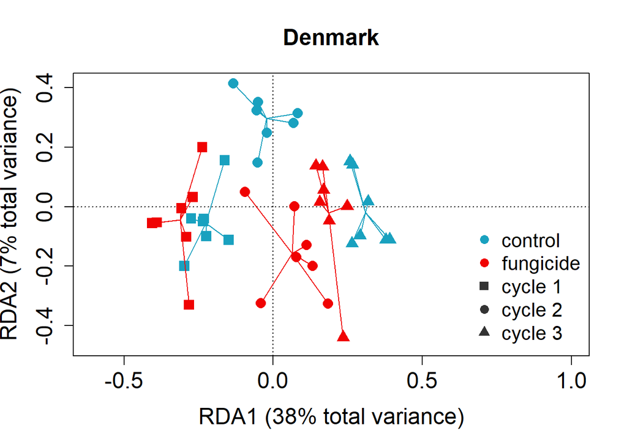

```r
scl = 'symmetric'
# arange size of single plot
si_sc <- scores(rda_species_DK_3, choices = 1:2, scaling = scl, display = 'sites')
sp_sc <- scores(rda_species_DK_3, choices = 1:2, scaling = scl, display = 'species')
va_sc <- scores(rda_species_DK_3, choices = 1:2, scaling = scl, display = 'cn')


# empty plot
p <- plot(rda_species_DK_3,
          scaling = 'symmetric',
          type = 'n',
          xlab =
            paste(attributes(summary(rda_species_DK_3)$cont$importance)$dimnames[[2]][1],
                     " (", round(summary(rda_species_DK_3)$cont$importance[2,1]*100),
                     "% total variance)", sep=""),
          ylab =
            paste(attributes(summary(rda_species_DK_3)$cont$importance)$dimnames[[2]][2],
                     " (", round(summary(rda_species_DK_3)$cont$importance[2,2]*100),
                     "% total variance)", sep=""),
          main = "Denmark", cex.lab = 1.5, cex.axis = 1.5, cex.main = 1.5)

# add points colored by fungicide treatment
cols <- c("#19A1BF", "#F00303")
# points shaped by cycle
pchs <- c(15, 16, 17)
points(si_sc,
       col = cols[Fak_conid_DK$fungicide],  # color by fungicide
       pch = pchs[Fak_conid_DK$cycle],      # shape by cycle
       cex = 1.5)

# legend will only be added in one of the three graphs
legend('bottomright',
       legend = c("control", "fungicide", paste0('cycle ', levels(Fak_conid_SW$cycle))),
       col = c(cols, 'grey20', 'grey20', 'grey20'),
       pch = c(rep(16, 2), 15, 16, 17), bty = "n", cex=1.3)

# connect single points per fungicide treatment and cycle
ordispider(p, interaction(Fak_conid_DK$cycle, Fak_conid_DK$fungicide),
           col = rep(cols, each = 3), label = F)
```

Plot for Gemamy

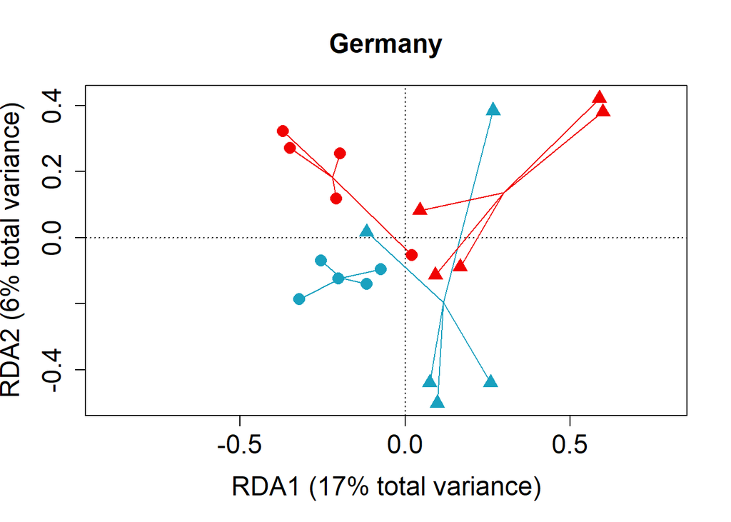

```r
scl = 'symmetric'
# arange size of single plot
si_sc <- scores(rda_species_DE_4, choices = 1:2, scaling = scl, display = 'sites')
sp_sc <- scores(rda_species_DE_4, choices = 1:2, scaling = scl, display = 'species')
va_sc <- scores(rda_species_DE_4, choices = 1:2, scaling = scl, display = 'cn')


# empty plot
p <- plot(rda_species_DE_4, scaling = 'symmetric', type = 'n',
          xlab =
            paste(attributes(summary(rda_species_DE_4)$cont$importance)$dimnames[[2]][1],
                     " (", round(summary(rda_species_DE_4)$cont$importance[2,1]*100),
                     "% total variance)", sep=""),
          ylab =
            paste(attributes(summary(rda_species_DE_4)$cont$importance)$dimnames[[2]][2],
                     " (", round(summary(rda_species_DE_4)$cont$importance[2,2]*100),
                     "% total variance)", sep=""),
          main = "Germany", cex.lab = 1.5, cex.axis = 1.5, cex.main = 1.5)

# add points colored by fungicide treatment
cols <- c("#19A1BF", "#F00303")
# points shaped by cycle
pchs <- c(16, 17)
points(si_sc,
       col = cols[Fak_conid_DE$fungicide],  # color by fungicide
       pch = pchs[Fak_conid_DE$cycle],      # shape by cycle
       cex = 1.5)

# connect singe points per fungicide treatment and cycle
ordispider(p, interaction(Fak_conid_DE$cycle, Fak_conid_DE$fungicide),
           col = rep(cols, each = 2), label = F)
```

For Sweden

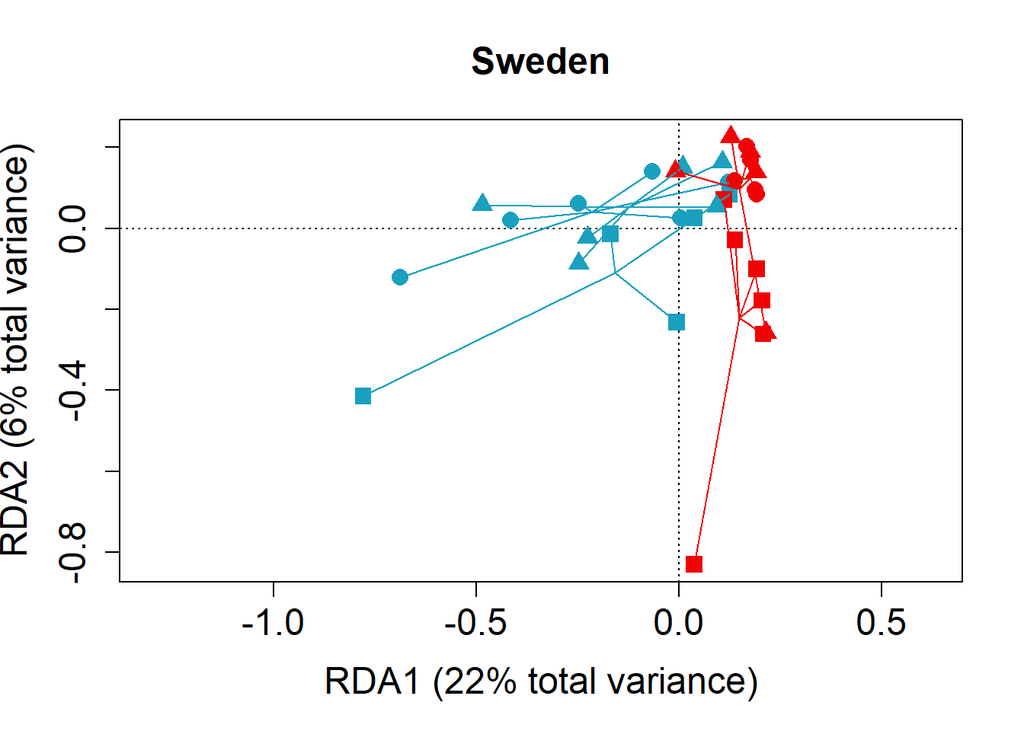

```r
scl = 'symmetric'
# arange size of single plot
si_sc <- scores(rda_species_SW_4, choices = 1:2, scaling = scl, display = 'sites')
sp_sc <- scores(rda_species_SW_4, choices = 1:2, scaling = scl, display = 'species')
va_sc <- scores(rda_species_SW_4, choices = 1:2, scaling = scl, display = 'cn')


# empty plot
p <- plot(rda_species_SW_4, scaling = 'symmetric', type = 'n',
          xlab =
            paste(attributes(summary(rda_species_SW_4)$cont$importance)$dimnames[[2]][1],
                     " (", round(summary(rda_species_SW_4)$cont$importance[2,1]*100),
                     "% total variance)", sep=""),
          ylab =
            paste(attributes(summary(rda_species_SW_4)$cont$importance)$dimnames[[2]][2],
                     " (", round(summary(rda_species_SW_4)$cont$importance[2,2]*100),
                     "% total variance)", sep=""),
          main = "Sweden", cex.lab=1.5, cex.axis = 1.5, cex.main=1.5)

# add points colored by fungicide treatment
cols <- c("#19A1BF", "#F00303")
# points shaped by cycle
pchs <- c(15, 16, 17)
points(si_sc,
       col = cols[Fak_conid_SW$fungicide],  # color by fungicide
       pch = pchs[Fak_conid_SW$cycle],      # shape by cycle
       cex = 1.5)


# connect singe points per fungicide treatment and cycle
ordispider(p, interaction(Fak_conid_SW$cycle, Fak_conid_SW$fungicide),
           col = rep(cols, each = 3), label = F)
```

```r
#dev.off()
```

## 1.9 Supplementary Material - Data Australia

#### 1.9.0.1 Model the data

##### 1.9.0.1.1 Fit model

We fit our model using:

```r
mod1_AUS_OMD <- lm(DLM ~ fungicide + cycle + fungicide:cycle,
           data = data_AUS)
```

##### 1.9.0.1.2 Diagnose model

First we check some model diagnostics:

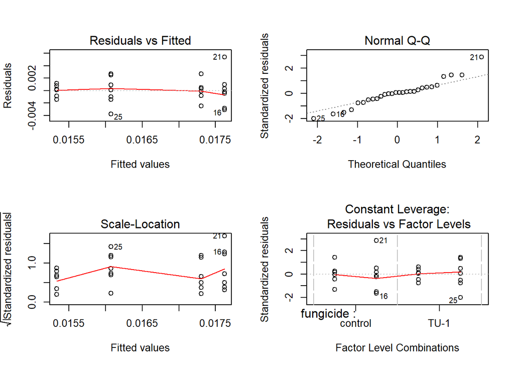

```r
par(mfrow = c(2, 2))
plot(mod1_AUS_OMD)
```

Model fits.

##### 1.9.0.1.3 Detailed look at interaction

Let’s futher investigate the differences using least-square means (lsmeans).

This calculates the lsmeans for fungicides within each cycle.

```r
lsm_AUS <- lsmeans(mod1_AUS_OMD, ~ fungicide | cycle)

lsm_dunn <- contrast(lsm_AUS, 'trt.vs.ctrl')
(lsm_dunn_sum <- summary(lsm_dunn, infer = TRUE, adjust = 'mvt'))
```

```
## cycle = 2:
##  contrast           estimate          SE df     lower.CL     upper.CL
##  TU-1 - control -0.001977760 0.001084447 24 -0.004215948 0.0002604275
##  t.ratio p.value
##   -1.824  0.0807
##
## cycle = 3:
##  contrast           estimate          SE df     lower.CL     upper.CL
##  TU-1 - control -0.001549406 0.001084447 24 -0.003787594 0.0006887825
##  t.ratio p.value
##   -1.429  0.1660
##
## Confidence level used: 0.95
```

### 1.9.1 Calculating effect sizes + their standard deviations

```r
s_AUS <- as.data.frame(summary(lsm_AUS))
s_AUS$region <- c("Australia")
control <- s_AUS[s_AUS$fungicide =="control",]
names(control)[3] <- c("mean_control")
names(control)[6] <- c("lower_control")
names(control)[7] <- c("upper_control")
s_AUS <- s_AUS[s_AUS$fungicide =="TU-1",]
names(s_AUS)[3] <- c("mean_TU-1")
s_AUS <- cbind(s_AUS, control[c(3,6,7)])
s_AUS$mean <- ((s_AUS$`mean_TU-1` - s_AUS$mean_control) / s_AUS$mean_control)*100
s_AUS$lower_CI <- ((s_AUS$lower.CL - s_AUS$mean_control) / s_AUS$mean_control)*100
s_AUS$upper_CI <- ((s_AUS$upper.CL - s_AUS$mean_control) / s_AUS$mean_control)*100

s_AUS$lower_cont_CI <- ((s_AUS$lower_control - s_AUS$mean_control) / s_AUS$mean_control)*100
s_AUS$upper_cont_CI <- ((s_AUS$upper_control - s_AUS$mean_control) / s_AUS$mean_control)*100
c1 <-data.frame(NA,"1",NA,NA, NA, NA, NA, "Australia", NA, NA, NA, NA, NA, NA, NA, NA)
names(c1) <- names(s_AUS)
s_AUS <- rbind(c1, s_AUS)
s_AUS$sig <- c("", "", "")
s_AUS$lab <- c("NA", "", "")
```

### 1.9.2 preparing Supplementary Fig. 1

For Australia

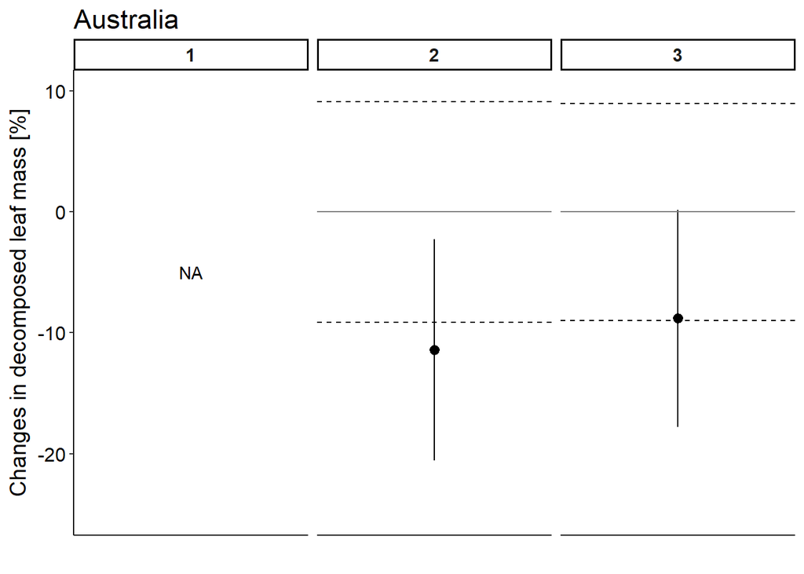

```r
# svg(filename="DLM_AUS.svg", width=4, height=4, pointsize=12)
ggplot(s_AUS, aes(x = region))+
  geom_pointrange(aes(y = mean, ymin = lower_CI, ymax = upper_CI))+
    geom_hline(aes(yintercept = c(NA, 0,0)), linetype = 'solid', colour="grey50") +
    geom_hline(aes(yintercept = lower_cont_CI), linetype = 'dashed') +
    geom_hline(aes(yintercept = upper_cont_CI), linetype = 'dashed') +
    facet_wrap(~cycle) +
  # scale_color_manual(values = c('grey30','black')) +
  ylab('Changes in decomposed leaf mass [%]')+
  xlab("")+
  ylim(-25,10)+
  ggtitle("Australia")+
  geom_text(aes(x=1,y=30,label=sig), cex=8) +
  theme_classic()+
  theme(axis.text.x = element_blank(), axis.ticks.x = element_blank(),
        axis.text.y = element_text(colour="black", size = 12),
        legend.position="none", strip.text.x = element_text(face = "bold" ),
       text = element_text(size=14))+
  geom_text(aes(x=1,y=-5,label=lab))
```

```r
# dev.off()
```

Colouring of the colonisation cycles (boxes on the top) afterwards in inkscape.

## 1.10 Supplementary Material - hyphomycete taxa richness

Calculating respective CI of taxa richness

```r
species_all <- group.CI(species ~ region + fungicide + cycle,
         data=data_all,
         ci = 0.95)
```

### 1.10.1 dividing these for regions

```r
species_DE <- species_all[species_all$region =="Germany",]
c1 <-data.frame("Germany","control","1",NA, NA, NA)
names(c1) <- names(species_DE)
species_DE <- rbind(c1, species_DE)
species_DE$lab <- c("NA", "", "", "",  "")

species_DK <- species_all[species_all$region =="Denmark",]

species_SW <- species_all[species_all$region =="Sweden",]
species_SW$fungicide <- gsub("TU-1", "fungicide", species_SW$fungicide)
```

### 1.10.2 Prepare Supplementary Fig. 2

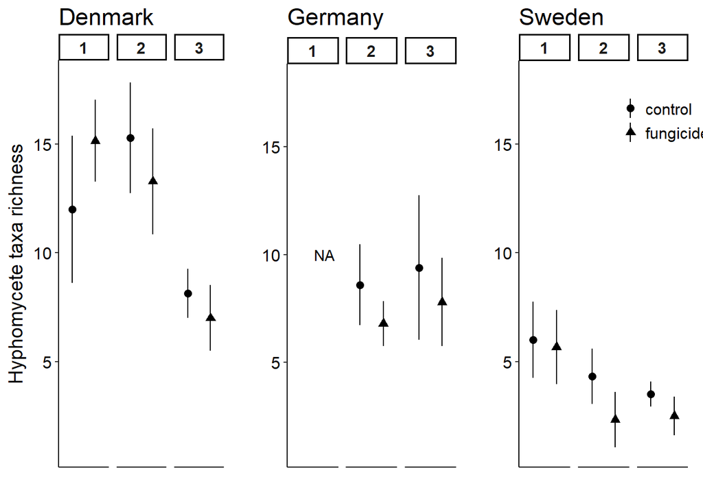

```r
p1_species <- ggplot(species_DK, aes(x = fungicide)) +
  geom_pointrange(aes(y = species.mean, ymin = species.lower,
                      ymax = species.upper, shape= fungicide))+
  facet_wrap(~cycle)+
  ylab('Hyphomycete taxa richness')+
  xlab("")+
  ylim(1,18)+
  ggtitle("Denmark")+
  theme_classic()+
  theme(axis.text.x = element_blank(),
        axis.ticks.x = element_blank(),axis.text.y = element_text(colour="black",
                                                                  size = 12),
        legend.position="none", strip.text.x = element_text(face = "bold" ),
        text = element_text(size=14))

p2_species <- ggplot(species_DE, aes(x = fungicide)) +
  geom_pointrange(aes(y = species.mean, ymin = species.lower, ymax = species.upper,
                      shape= fungicide))+
  facet_wrap(~cycle)+
  ylab('')+
  xlab("")+
  ylim(1,18)+
  ggtitle("Germany")+
  theme_classic()+
  theme(axis.text.x = element_blank(),
        axis.ticks.x = element_blank(),axis.text.y = element_text(colour="black",
                                                                  size = 12),
        legend.position="none", strip.text.x = element_text(face = "bold" ),
        text = element_text(size=14)) + geom_text(aes(x=2,y=10,label=lab))

p3_species <- ggplot(species_SW, aes(x = fungicide)) +
  geom_pointrange(aes(y = species.mean, ymin = species.lower, ymax = species.upper,
                      shape= fungicide))+
  facet_wrap(~cycle)+
  ylab('')+
  xlab("")+
  ylim(1,18)+
  ggtitle("Sweden")+
  theme_classic()+
  theme(axis.text.x = element_blank(),
        axis.ticks.x = element_blank(),axis.text.y = element_text(colour="black",
                                                                  size = 12),
        legend.position = c(0.85, 0.86), strip.text.x = element_text(face = "bold" ),
        text = element_text(size=14), legend.title = element_blank())


# svg(filename="Taxa_richness.svg", width=10, height=4, pointsize=12)
ggdraw() +
  draw_plot(p1_species, x = 0, y = 0, width = .33, height = 1) +
  draw_plot(p2_species, x = .33, y = 0, width = .33, height = 1) +
  draw_plot(p3_species, x = 0.66, y = 0, width = 0.33, height = 1)
```

```r
# dev.off()
```

Colouring of the colonisation cycles (boxes on the top) afterwards in inkscape.

## 1.11 Supplementary Material - Absolute DLM

Calculating respective CI of DLM

```r
data_all$DLM <- data_all$DLM*1000
DLM_all <- group.CI(DLM ~ region + fungicide + cycle,
         data=data_all,
         ci = 0.95)
```

### 1.11.1 dividing data for regions

```r
DLM_DE <- DLM_all[DLM_all$region =="Germany",]

DLM_DK <- DLM_all[DLM_all$region =="Denmark",]

DLM_SW <- DLM_all[DLM_all$region =="Sweden",]
DLM_SW$fungicide <- gsub("TU-1", "fungicide", DLM_SW$fungicide)
```

### 1.11.2 preparing Supplementary Fig. 3

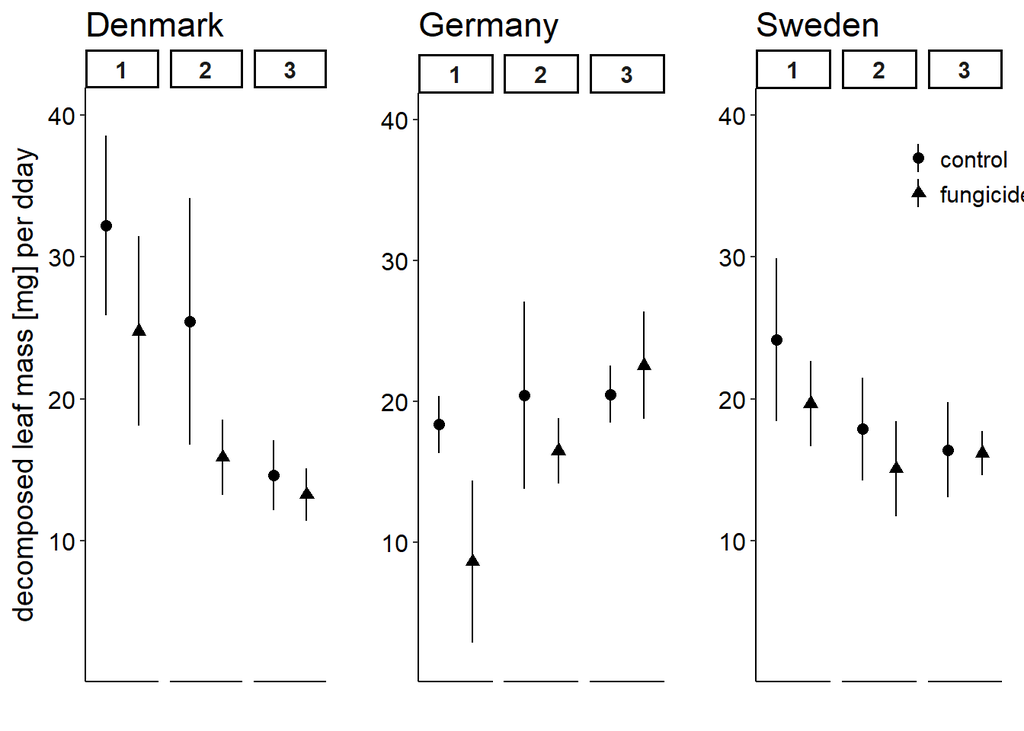

```r
p1_DLM <- ggplot(DLM_DK, aes(x = fungicide)) +
  geom_pointrange(aes(y = DLM.mean, ymin = DLM.lower, ymax = DLM.upper, shape= fungicide))+
  facet_wrap(~cycle)+
  ylab('decomposed leaf mass [mg] per dday')+
  xlab("")+
  ylim(2,40)+
  ggtitle("Denmark")+
  theme_classic()+
  theme(axis.text.x = element_blank(),
        axis.ticks.x = element_blank(),axis.text.y = element_text(colour="black",
                                                                  size = 12),
        legend.position="none", strip.text.x = element_text(face = "bold" ),
        text = element_text(size=14))

p2_DLM <- ggplot(DLM_DE, aes(x = fungicide)) +
  geom_pointrange(aes(y = DLM.mean, ymin = DLM.lower, ymax = DLM.upper, shape= fungicide))+
  facet_wrap(~cycle)+
  ylab('')+
  xlab("")+
  ylim(2,40)+
  ggtitle("Germany")+
  theme_classic()+
  theme(axis.text.x = element_blank(),
        axis.ticks.x = element_blank(),axis.text.y = element_text(colour="black",
                                                                  size = 12),
        legend.position="none", strip.text.x = element_text(face = "bold" ),
        text = element_text(size=14))

p3_DLM <- ggplot(DLM_SW, aes(x = fungicide)) +
  geom_pointrange(aes(y = DLM.mean, ymin = DLM.lower, ymax = DLM.upper, shape= fungicide))+
  facet_wrap(~cycle)+
  ylab('')+
  xlab("")+
  ylim(2,40)+
  ggtitle("Sweden")+
  theme_classic()+
  theme(axis.text.x = element_blank(),
        axis.ticks.x = element_blank(),axis.text.y = element_text(colour="black",
                                                                  size = 12),
        legend.position = c(0.85, 0.86), strip.text.x = element_text(face = "bold" ),
        text = element_text(size=14), legend.title = element_blank())


# svg(filename="DLM_absolute_values.svg", width=10, height=4, pointsize=12)
ggdraw() +
  draw_plot(p1_DLM, x = 0, y = 0, width = .33, height = 1) +
  draw_plot(p2_DLM, x = .33, y = 0, width = .33, height = 1) +
  draw_plot(p3_DLM, x = 0.66, y = 0, width = 0.33, height = 1)
```

```r
# dev.off()
```

Colouring of the colonisation cycles (boxes on the top) afterwards in inkscape.